# (PART) 穩健統計方法 Robust Statistic Methods

# 穩健統計方法入門

> **Statistical thinking will one day be as necessary a qualification for efficient citizenship as the ability to read and write.**

> H.G. Wells

The Robust Statistic Methods lectures were orgainised and taught by Professor [Richard Silverwood](https://iris.ucl.ac.uk/iris/browse/profile?upi=RSILV59).

# 基於秩次的非參數檢驗

基於秩次的統計學方法不像其他參數檢驗那樣需要太多的假設和前提 (比如服從正態分佈或者其它假設)。這類方法其實放棄了數據的部分信息 – 那就是數據之間值的差距。通過給數據排序列，我們僅僅知道數據的排序。所以我們可以下結論說 $A$ 大於 $B$，或者 $B$ 大於 $C$ (因此 $A$ 也大於 $C$)，但是他們之間數值的差距被忽略掉了 (所以我們不能比較 $A-B$ 和 $B-C$ 的大小)。

所以，基於秩次的統計學方法完全只依賴數據的大小**排序**，觀察獲得數據的真實大小被忽視了。

## 符號檢驗 the Sign test

我們以下列一組空腹血糖測量值的數據爲例：

Fasting Glucose Level (mmol/L)

| n=24 Diabetics | n=24 Diabetics | n=24 Diabetics |
| --- | --- | --- |
| 10.3 | 8.8 | 5.3 |
| 9.5 | 6.7 | 6.7 |
| 12.2 | 12.5 | 5.2 |
| 15.1 | 4.2 | 13.3 |
| 10.8 | 15.3 | 7.5 |
| 19.0 | 7.2 | 4.9 |
| 16.1 | 9.3 | 19.5 |
| 8.1 | 8.6 | 11.1 |

我們如果想要對這組數據的中位數做出假設檢驗，$H_0: \theta = 10; \text{ v.s. } H_1: \theta\neq10$。

該選擇哪種檢驗方法來回答這個假設檢驗提出的問題：中位數是否等於 $10$?

符號檢驗 (the *sign test*)，可以用來輔助我們對數據的中位數 (median $\theta$) 作出推斷 (inference)。雖然往下看你會發現嚴格說來這並不算是基於秩次的檢驗方法。使用符號檢驗時我們需要的唯一假設：數據來自連續分佈 (continuous distribution)。

這種類型的檢驗方法常用的假設檢驗如下：

$$H_0: \theta=\theta_0 \\
H_1: \theta\neq\theta_0$$

其中，$\theta_0$ 就是我們想要檢驗的中位數的大小，在上面的例子中，$\theta_0=10$。

此時我們用到的檢驗統計量，$X$ 的定義是：樣本數據中比 $\theta_0$ 大的數據個數，和比 $\theta_0$ 小的數據個數，兩個個數中較小的那一個。因爲在零假設的條件下，如果觀察數據的中位數等於 $\theta_0$ 的話，數據中比 $\theta_0$ 大或者小的數據個數應該是相等的。可以用一個二項分佈，概率爲 $0.5$ 的模型來模擬：

$$X\sim Bin(n, 0.5)$$

在本例中，觀察數據有 13 個小於 $\theta_0=10$，有 11 個大於 $\theta_0=10$。因此 $X=11, n=24$。假如 $\pi$ 是一個觀察數據大於 $\theta_0$ 的概率的話，在零假設的條件下，$H_0: \pi=0.5$。檢驗這個假設的雙側概率的計算公式爲：

$$2\times P(X\leqslant
x|\pi=0.5)$$

在本例中， $X=11$。如果（像在考試的時候沒有電腦輔助）要用查表的方式判斷 $p$ 值大小。可以先[下載](http://onlinelibrary.wiley.com/doi/10.1002/9780470776124.app1/pdf) 一份統計數據的表格。下載好了找到 “Statistical Table 7.1 Critical one- and two-tailed values of x for a Sign test” 在第185頁：(下面只是截圖)

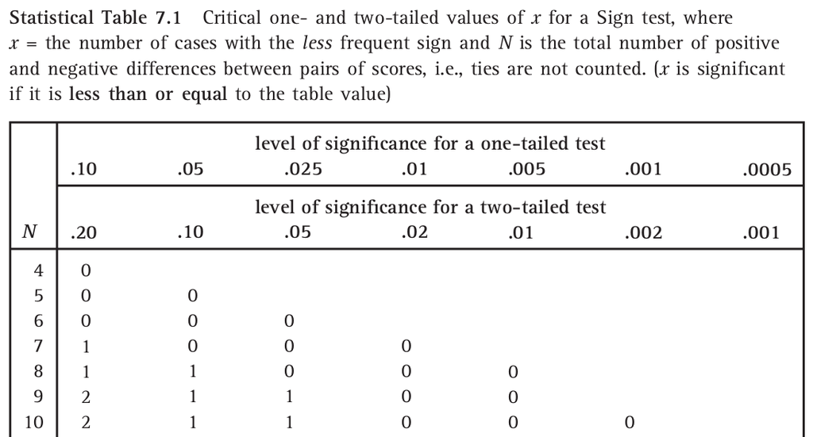

$$\cdots\cdots\cdots$$

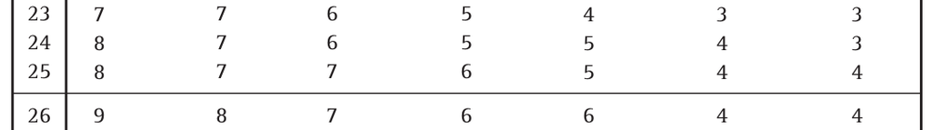

Critical Values for a Sign test

找到 $n=24$ 這一行，發現顯著性水平是 $20\%$ 的拒絕域都要小於 $8$， 所以本例的 $p>20\%$。

如果你很幸運沒有在考場上，那麼可以找出自己的電腦下載好 [R](https://www.r-project.org/) 之後執行下面的命令：

```r
2*pbinom(11,24, 0.5)
```

```
## [1] 0.8388
```

或者可以使用命令 `binom.test` 來做一個二項分佈的概率檢驗：

```r
options(scipen = 1, digits = 8) # just to show the p values are exactly the same
binom.test(11,24,0.5)
```

```
##
##  Exact binomial test
##
## data:  11 and 24
## number of successes = 11, number of trials = 24, p-value = 0.83882
## alternative hypothesis: true probability of success is not equal to 0.5
## 95 percent confidence interval:
##  0.25553020 0.67179192
## sample estimates:
## probability of success
##             0.45833333
```

或者你也可以使用 [`BSDA`](https://alanarnholt.github.io/BSDA/) 中的 `SIGN.test` 命令來進行一場轟轟烈烈的符號檢驗：

```r
options(scipen = 1, digits = 8)
# input the data
dt <- c(10.3,9.5,12.2,15.1,10.8,19.0,16.1, 8.1, 8.8, 6.7,12.5, 4.2,15.3, 7.2, 9.3, 8.6, 5.3,6.7 ,5.2,13.3, 7.5, 4.9,19.5,11.1)
BSDA::SIGN.test(dt, md=10, alternative="two.sided", conf.level=0.95)
```

```
##
##  One-sample Sign-Test
##
## data:  dt
## s = 11, p-value = 0.83882
## alternative hypothesis: true median is not equal to 10
## 95 percent confidence interval:
##   7.3988241 12.3011759
## sample estimates:
## median of x
##         9.4
##
## Achieved and Interpolated Confidence Intervals:
##
##                   Conf.Level L.E.pt  U.E.pt
## Lower Achieved CI     0.9361 7.5000 12.2000
## Interpolated CI       0.9500 7.3988 12.3012
## Upper Achieved CI     0.9773 7.2000 12.5000
```

“據說”如果你用 [`Stata`](https://www.stata.com/) 的話還會給你一個絢麗的表格：

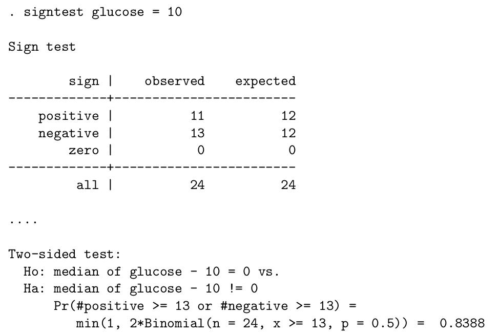

The Stata output of a Sign Test

總而言之無論你用的是哪個方法，查 (水) 表法或是統計武俠包，結果都是一樣的：數據無法提供足夠的證據拒絕零假設，即無證據證明中位數不等於10。

需要注意的是，如果觀察數據中有的值恰好等於 $\theta_0$ 那麼這些觀察數據就會被剔除之後再進行檢驗，相應的樣本量 ($n$) 也就變小了。如果觀察數據樣本量足夠大，我們可以使用二項分佈的正態分佈近似 (Section @ref(binomial-normal-approx)) 法計算。近似法計算時記得要進行校正 (Section @ref(continuity-correction))：

$$z=\frac{\frac{x}{n}-\pi}{\sqrt{\pi(1-\pi)/n}}=\frac{\frac{x}{n}-0.5}{\sqrt{0.5(1-0.5)/n}}=\frac{2x}{\sqrt{n}}-\sqrt{n}\\
\text{With the continuity correction, this becomes: }\\
z=\lvert\frac{2x}{\sqrt{n}}-\sqrt{n}\rvert-\frac{1}{\sqrt{n}}$$

在本例中：

$$z=\lvert\frac{2\times11}{\sqrt{24}}-\sqrt{24}\rvert-\frac{1}{\sqrt{24}}=0.204$$

標準正態分佈的 $z$ 爲 $0.204$ 時的雙側 $p$ 值爲：

```r
(1-pnorm(0.204))*2
```

```
## [1] 0.8383535
```

和前面的直接計算法的結果還算是十分接近滴。

### 符號檢驗的特點

符號檢驗十分的穩健 (Robust)，因爲我們除了數據連續性的假設之外沒有其他任何假設。但是穩健檢驗是有代價的。因爲進行符號檢驗的同時意味着我們要放棄一個個數據本身能提供的信息。結果導致這類檢驗敏感度較低，檢驗效能 (Power) 較差，以及獲得的信賴區間也就很寬 (不精確)。

## Wilcoxon 符號秩和檢驗，the Wilcoxon signed-rank test

Wilcoxon 符號秩和檢驗也可以用來檢驗一組數據的中位數是否和某個已知數字相等。進行本方法時除了像符號檢驗那樣要假設數據是連續的以外，還要假設數據的分佈是左右對稱的。因此，由於假定了左右對稱的前提，中位數也就等於均數，所以它也可以被用於檢驗均數是否等於某個已知的值。

Wilcoxon 符號秩和檢驗的前提可以被認爲是介於符號檢驗和單一樣本 $t$ 檢驗 (還假設數據來自於正態分佈) 之間的一種檢驗。

當一組隨機觀察數據 $x_1,\cdots,x_n$ 來自於對稱的連續分佈數據。如果它的中位數是 $\theta$，在零假設：$H_0: \theta=\theta_0$ 的條件下：

1. 將全部觀察數據一一和 $\theta_0$ 相減，那麼每一個 $d_i=x_i-\theta_0, i=1,2,\cdots,n$ 的正負符號概率是相等的；
2. 任何一個和 $\theta_0$ 相減之後的差 $\lvert d_i \lvert$ ，取正負符號的概率是相等的。

這裏我們使用另一個例子來說明 Wilcoxon 檢驗法。下列數據爲，12名女性從平躺姿勢改成直立時心跳次數的變化 (次/分)。

`-2, -5, 12, 4, 16, 17, 8, 3, 20, 25, 1, 9`

下面來使用 Wilcoxon 符號秩和檢驗法來檢驗中位數 $\theta=15$。

首先，先計算每個數據和 $15$ 之間的差值：

```r
data <- c(-2, -5, 12, 4, 16, 17, 8, 3, 20, 25, 1, 9)
newdata <- data-15
newdata
```

```
##  [1] -17 -20  -3 -11   1   2  -7 -12   5  10 -14  -6
```

下一步，計算這些差值的絕對值：

```r
abs_newdata <- abs(newdata)
abs_newdata
```

```
##  [1] 17 20  3 11  1  2  7 12  5 10 14  6
```

```r
Dt <- data.frame(data, newdata, abs_newdata)
Dt <- Dt[order(newdata), ] # sort the data by newdata
Dt
```

```
##    data newdata abs_newdata
## 2    -5     -20          20
## 1    -2     -17          17
## 11    1     -14          14
## 8     3     -12          12
## 4     4     -11          11
## 7     8      -7           7
## 12    9      -6           6
## 3    12      -3           3
## 5    16       1           1
## 6    17       2           2
## 9    20       5           5
## 10   25      10          10
```

之後，給絕對值排序：

```r
Dt$ranks <- rank(Dt$abs_newdata)
Dt
```

```
##    data newdata abs_newdata ranks
## 2    -5     -20          20    12
## 1    -2     -17          17    11
## 11    1     -14          14    10
## 8     3     -12          12     9
## 4     4     -11          11     8
## 7     8      -7           7     6
## 12    9      -6           6     5
## 3    12      -3           3     3
## 5    16       1           1     1
## 6    17       2           2     2
## 9    20       5           5     4
## 10   25      10          10     7
```

接下來，給小於 $15$ 的數據的排序加上負號：

```r
Dt$signed_ranks <- ifelse(Dt$newdata < 0, Dt$ranks*(-1), Dt$ranks)
Dt <- Dt[order(Dt$ranks),]
Dt
```

```
##    data newdata abs_newdata ranks signed_ranks
## 5    16       1           1     1            1
## 6    17       2           2     2            2
## 3    12      -3           3     3           -3
## 9    20       5           5     4            4
## 12    9      -6           6     5           -5
## 7     8      -7           7     6           -6
## 10   25      10          10     7            7
## 4     4     -11          11     8           -8
## 8     3     -12          12     9           -9
## 11    1     -14          14    10          -10
## 1    -2     -17          17    11          -11
## 2    -5     -20          20    12          -12
```

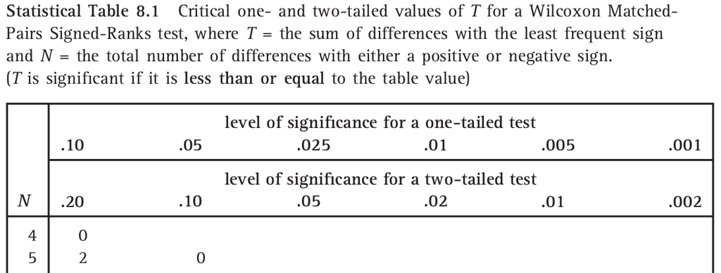

$$\cdots\cdots\cdots$$

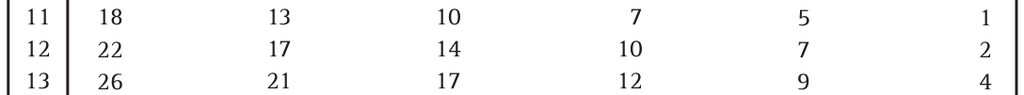

Critical Values for a Wilcoxon Signed-Ranks test

精確的 Wilcoxon 符號秩和檢驗可以通過下列代碼在 [R](https://www.r-project.org/) 裏完成：

```r
wilcox.test(Dt$data, mu=15, paired = FALSE)
```

```
##
##  Wilcoxon signed rank exact test
##
## data:  Dt$data
## V = 14, p-value = 0.052246
## alternative hypothesis: true location is not equal to 15
```

如果數據中有觀察值和我們希望比較的數值完全相等的話，和符號檢驗類似的，這些觀察值需要被剔除之後再進行上面的個步驟檢驗。記得還要將樣本量減去相應個數再去查表尋找 $p$ 值。

另外，下面的代碼可以計算正態分佈近似的 Wilcoxon 秩和檢驗，結果十分接近：

```r
wilcox.test(Dt$data, mu=15, paired = FALSE, exact = FALSE, correct = FALSE)
```

```
##
##  Wilcoxon signed rank test
##
## data:  Dt$data
## V = 14, p-value = 0.04986
## alternative hypothesis: true location is not equal to 15
```

## Wilcoxon-Mann-Whitney (WMW) 檢驗

本方法用於比較兩組獨立樣本的分佈是否只是**左右位移 (或者叫平移)**。此檢驗需要的假設前提爲：兩組獨立樣本來自連續型分佈，且僅僅只存在整體的**左右位移 (或者叫平移)** (location shift)。

例如說，兩組數據各自的累積概率方程分別是 $F(\cdot), G(\cdot)$ 時，由上面的假設可知：

$$G(y)=F(y-\Delta), \text{ where }
-\infty<\Delta<\infty$$

上面式子中的 $\Delta$ 就是所謂的 **“左右位移 (或者叫平移)”**。因此本檢驗的零假設和替代假設爲：

$$H_0: \Delta=0\\
H_1: \Delta\neq0$$

在零假設的條件下，我們可以認爲兩個樣本來自相同的人羣分佈。假如，$F, G$ 都是正態分佈，且同方差。那麼 $\Delta$ 就等於兩個分佈的均值差。在這種情況下就可以使用兩樣本 $t$ 檢驗。所以說，WMW 檢驗其實就是把假設前提放寬了的 (免去了正態分佈假設) 兩樣本 $t$ 檢驗。

如果兩個獨立樣本分別有樣本量 $n, m, \text{ and } n<m$：$X_1,\cdots,X_n$ 和 $Y_1, \cdots, Y_m$。在零假設的條件下，將這兩個樣本合併之後的大樣本 ($m+n$ 個樣本量) ：$X_1,\cdots,X_n,Y_1, \cdots, Y_m$ 可以視爲來自同一分佈。那麼在合併後的樣本中，我們給每一個元素賦予它們的合併後數據中的排序 ($\text{Rank}_i: i= 1,2,\cdots,n, n+1, \cdots, n+m$)。那麼我們感興趣的 Wilcoxon 秩和統計量 (Wilcoxon rank sum statistic) $W_1$ 是樣本量較小的那些數字在合併後數據中的排序之和。

$$W_1=\sum_{i=1}^n R_i$$

對於大小相同的數據，排序取他們的排序的平均值。

最後拿來判斷的檢驗統計量是 $U_1$ 和 $n\times m -U_1$ 兩者中較小的數字。(注：如果我們一開始計算樣本量較多的部分的秩和 $W_2=\sum_{i=1}^m R_i$ 時，將計算的 $U_2=W_2-\frac{m(m+1)}{2}$，跟 $n\times m - U_2$ 中較小的數字作爲檢驗統計量的話，我們會在數學上獲得完全一樣的檢驗統計量。)

其實兩個統計量 $W, U$ 均可以用來作相同的統計推斷，當然各自的 $p$ 值表格不同。但是 $U$ 有另外一種統計學含義：$U$ 是 $X_i>Y_j$， 也就是所有的 $(X_i, Y_j)$ 配對中 $X_i$ 較大的對的個數。

這裏使用下面的例子來解釋如何操作 WMW 檢驗： 採集16名甲亢兒童的血清甲狀腺素濃度值列表如下，

Serum thyroxine levels

| n=16 hypothyroid children thyr | n=16 hypothyroid children group |
| --- | --- |
| 34 | Slight or no symptoms |
| 45 | Slight or no symptoms |
| 49 | Slight or no symptoms |
| 55 | Slight or no symptoms |
| 58 | Slight or no symptoms |
| 59 | Slight or no symptoms |
| 60 | Slight or no symptoms |
| 62 | Slight or no symptoms |
| 86 | Slight or no symptoms |
| 5 | Marked symptoms |
| 8 | Marked symptoms |
| 18 | Marked symptoms |
| 24 | Marked symptoms |
| 60 | Marked symptoms |
| 84 | Marked symptoms |
| 96 | Marked symptoms |

這裏我們需要比較輕微症狀組和嚴重症狀組的血清甲狀腺濃度的分佈是否只是左右位移，$H_0: \Delta=0$。

首先，我們要給兩組合併後的濃度排序：

```r
dt$rank <- rank(dt$thyr)
dt <- dt[order(dt$rank),]
dt
```

```
##    thyr                 group rank
## 10    5       Marked symptoms  1.0
## 11    8       Marked symptoms  2.0
## 12   18       Marked symptoms  3.0
## 13   24       Marked symptoms  4.0
## 1    34 Slight or no symptoms  5.0
## 2    45 Slight or no symptoms  6.0
## 3    49 Slight or no symptoms  7.0
## 4    55 Slight or no symptoms  8.0
## 5    58 Slight or no symptoms  9.0
## 6    59 Slight or no symptoms 10.0
## 7    60 Slight or no symptoms 11.5
## 14   60       Marked symptoms 11.5
## 8    62 Slight or no symptoms 13.0
## 15   84       Marked symptoms 14.0
## 9    86 Slight or no symptoms 15.0
## 16   96       Marked symptoms 16.0
```

Wilcoxon 統計量 $W_1$ 是人數少的組的排序之數值和。本樣本中 7 人有嚴重症狀，9人有輕微或無症狀。所以 $W_1$ 就是嚴重症狀組的秩和：

$$W_1=1+2+3+4+11.5+14+16=51.5$$

再計算統計量 $U_1$：

$$U_1=W_1-\frac{n(n+1)}{2}=51.5-\frac{7\times(7+1)}{2}=23.5$$

所以 $n\times m-U_1=7\times9-23.5=39.5$，顯然這兩個數值中小的 $23.5$ 就是我們尋找的 WMW 統計量。繼續查水錶：

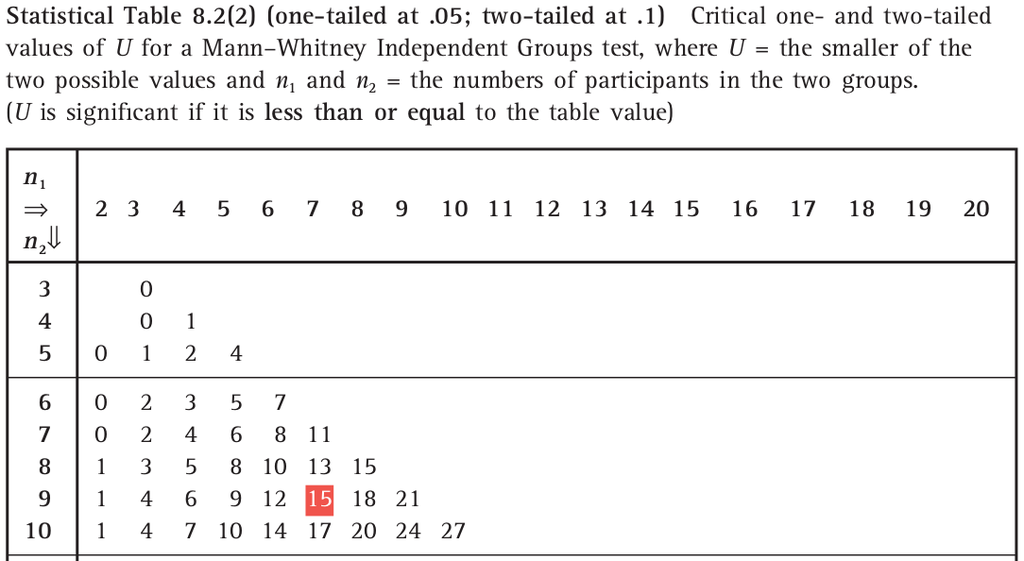

Critical Values of U for a Wilcoxon-Mann-Whitney test

可知 $n_1=7, n_2=9$ 時，統計量要低於 $15$ $p$ 值才會小於 $0.1$。所以數據給出的 $p>0.1$。

在 [R](https://www.r-project.org/) 裏面用下面的代碼進行 WHW 檢驗：

```r
wilcox.test(dt$thyr~dt$group, correct=FALSE) # without continuity correction
```

```
##
##  Wilcoxon rank sum test
##
## data:  dt$thyr by dt$group
## W = 23.5, p-value = 0.39675
## alternative hypothesis: true location shift is not equal to 0
```

```r
wilcox.test(dt$thyr~dt$group) # with continuity correction i.e. normal appriximation
```

```
##
##  Wilcoxon rank sum test with continuity correction
##
## data:  dt$thyr by dt$group
## W = 23.5, p-value = 0.42692
## alternative hypothesis: true location shift is not equal to 0
```

## 秩相關，Spearman’s Rank Correlation Coefficient

Spearman 的秩相關 (通常用 $\rho$)，是一種基於數據排序的相關係數算法。和傳統的 Pearson 相關係數類比，是當數據無法被認定是線性相關時的另一種相關關係檢驗方法。所以秩相關不假定兩組數據之間是線性相關 (linear association)。秩相關只關心一個數據遞增時，另一個數據是否單調遞增。所以可以用於傾向性檢驗。

具體的操作是，在兩組數據中先各自排序，像所有的排序檢驗一樣遇到相同大小的數值將排序取均值。之後使用一般的求相關係數的方法。本法中只用到了數值在各自組中的排序，並沒有使用他們的真實大小。近似法的秩相關計算公式爲：

$$\hat\tau=\frac{\hat\rho}{\sqrt{(1-\hat\rho^2)/(n-2)}}$$

在零假設條件下 $H_0: \rho=0$，上面的近似法秩相關服從 $t_{n-2}$ 分佈。 下面用某血友病患者調查數據獲得的血液 $T_4, T_8$ 淋巴球計數 $(\times10^9/\ell)$ 來詳細解釋計算過程：

Lymphocyte counts

| n=28 haemophiliacs th4 | n=28 haemophiliacs th8 |
| --- | --- |
| 0.20 | 0.17 |
| 0.27 | 0.52 |
| 0.28 | 0.25 |
| 0.37 | 0.34 |
| 0.38 | 0.14 |
| 0.48 | 0.10 |
| 0.49 | 0.58 |
| 0.56 | 0.23 |
| 0.60 | 0.24 |
| 0.64 | 0.67 |
| 0.64 | 0.90 |
| 0.66 | 0.26 |
| 0.70 | 0.61 |
| 0.77 | 0.18 |
| 0.88 | 0.74 |
| 0.88 | 0.54 |
| 0.88 | 0.76 |
| 0.90 | 0.62 |
| 1.02 | 0.48 |
| 1.10 | 0.58 |
| 1.10 | 0.34 |
| 1.18 | 0.84 |
| 1.20 | 0.63 |
| 1.30 | 0.46 |
| 1.40 | 0.84 |
| 1.60 | 1.20 |
| 1.64 | 0.59 |
| 2.40 | 1.30 |

給這組數據繪製散點圖：

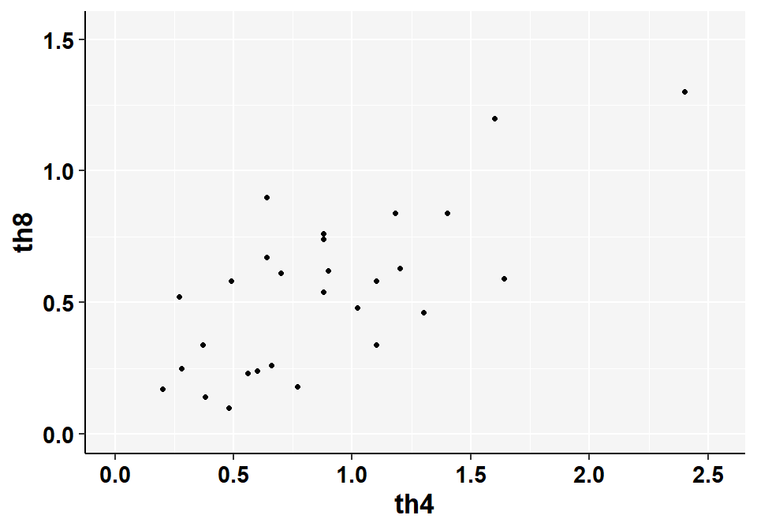

Scatter plot of T4 and T8 counts

可以看見圖中右上角的兩個點幾乎可以認爲是異常值 (outliers)。 分別給 `th4, th8` 求各自的排序：

```r
dt$rank4 <- rank(dt$th4)
dt$rank8 <- rank(dt$th8)
kable(dt, "html", align = "c",caption = "Lymphocyte counts") %>%
  kable_styling(bootstrap_options = c("striped", "bordered")) %>%
#  collapse_rows(columns = c(1)) %>%
  add_header_above(c("n=28 haemophiliacs with ranks" = 4)) %>%
    scroll_box(width = "400px", height = "500px", extra_css="margin-left: auto; margin-right: auto;")
```

Lymphocyte counts

| n=28 haemophiliacs with ranks th4 | n=28 haemophiliacs with ranks th8 | n=28 haemophiliacs with ranks rank4 | n=28 haemophiliacs with ranks rank8 |
| --- | --- | --- | --- |
| 0.20 | 0.17 | 1.0 | 3.0 |
| 0.27 | 0.52 | 2.0 | 13.0 |
| 0.28 | 0.25 | 3.0 | 7.0 |
| 0.37 | 0.34 | 4.0 | 9.5 |
| 0.38 | 0.14 | 5.0 | 2.0 |
| 0.48 | 0.10 | 6.0 | 1.0 |
| 0.49 | 0.58 | 7.0 | 15.5 |
| 0.56 | 0.23 | 8.0 | 5.0 |
| 0.60 | 0.24 | 9.0 | 6.0 |
| 0.64 | 0.67 | 10.5 | 21.0 |
| 0.64 | 0.90 | 10.5 | 26.0 |
| 0.66 | 0.26 | 12.0 | 8.0 |
| 0.70 | 0.61 | 13.0 | 18.0 |
| 0.77 | 0.18 | 14.0 | 4.0 |
| 0.88 | 0.74 | 16.0 | 22.0 |
| 0.88 | 0.54 | 16.0 | 14.0 |
| 0.88 | 0.76 | 16.0 | 23.0 |
| 0.90 | 0.62 | 18.0 | 19.0 |
| 1.02 | 0.48 | 19.0 | 12.0 |
| 1.10 | 0.58 | 20.5 | 15.5 |
| 1.10 | 0.34 | 20.5 | 9.5 |
| 1.18 | 0.84 | 22.0 | 24.5 |
| 1.20 | 0.63 | 23.0 | 20.0 |
| 1.30 | 0.46 | 24.0 | 11.0 |
| 1.40 | 0.84 | 25.0 | 24.5 |
| 1.60 | 1.20 | 26.0 | 27.0 |
| 1.64 | 0.59 | 27.0 | 17.0 |
| 2.40 | 1.30 | 28.0 | 28.0 |

接下來再給 `th4, th8` 的排序做散點圖：

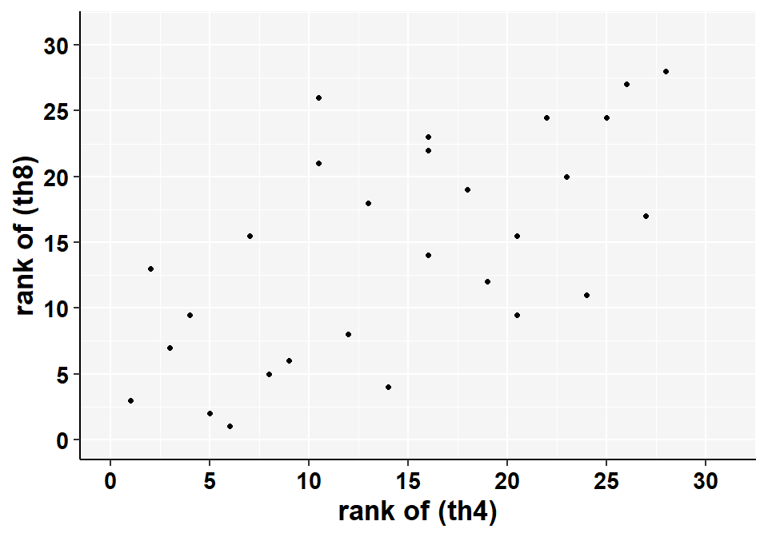

Scatter plot of T4 and T8 ranks

此時也就沒有了異常值的存在。對二者的排序計算相關係數：

```r
cor.test(dt$rank4, dt$rank8)
```

```
##
##  Pearson's product-moment correlation
##
## data:  dt$rank4 and dt$rank8
## t = 4.11513, df = 26, p-value = 0.00034606
## alternative hypothesis: true correlation is not equal to 0
## 95 percent confidence interval:
##  0.33297073 0.81107104
## sample estimates:
##        cor
## 0.62803129
```

```r
cor.test(dt$th4, dt$th8)
```

```
##
##  Pearson's product-moment correlation
##
## data:  dt$th4 and dt$th8
## t = 5.28031, df = 26, p-value = 0.000016061
## alternative hypothesis: true correlation is not equal to 0
## 95 percent confidence interval:
##  0.47328797 0.86128090
## sample estimates:
##        cor
## 0.71934766
```

秩相關的相關係數爲 $0.628$。而原始數據的相關係數爲 $0.719$。

## 基於秩次的非參數檢驗的優缺點

優點：

- 可以讓我們拋棄很多 (正態分佈等的) 前提假設，許多真實數據本身並不能滿足這些條件，這些情況下，基於秩次的非參數檢驗能提供更高的統計效能 (power)。

缺點：

- 如果數據本身能夠滿足如正態分佈之類的假設，那麼相比較與一般的參數檢驗，基於秩次的非參數檢驗法效能就偏低。
- 基於秩次的非參數檢驗較難推廣到更加複雜的情況。
- 這些檢驗法僅僅只能幫助我們進行假設檢驗。但是多數情況下，我們更加希望能使用觀察數據對總體進行點估計 (point estimates) 並且給出信賴區間 (CIs)。通常情況下，基於秩次的非參數檢驗法就很難給出這樣的估計。

# 排列置換法 Permutation procedures

## 背景介紹

Good[@good2006permutation] 曾經提出假設檢驗構建的步驟，這裡引用如下：

1. 分析問題，確認零假設 (null hypothesis)，和可能的替代假設 (alternative hypothesis)。確認這兩種假設決定以後可能伴隨的錯誤 (The potential risk associated with a decision)；
2. 選擇一個檢驗統計量；
3. 計算數據給出的檢驗統計量；
4. 確定檢驗統計量，在**零假設**時的**樣本分佈**；
5. 用確定好的樣本分佈，以及數據給出的統計量大小，做出決策！

本章要介紹的排列置換法 (permutation)，和下一章會介紹的自助重抽法 (bootstrap) ，需要大量的計算機的計算，和較強的電腦性能。這兩種方法有一個共同的特徵，它們都利用手頭獲得的樣本數據輔助生成**樣本分佈**，同時對該數據的分佈或者特質不進行假設。也就是用在上面羅列步驟的第4步。其餘的步驟則與一般的參數假設檢驗完全相同。

## 直接上實例

之前用過的甲亢數據：

Serum thyroxine levels

| n=16 hypothyroid children thyr | n=16 hypothyroid children group |
| --- | --- |
| 34 | Slight or no symptoms |
| 45 | Slight or no symptoms |
| 49 | Slight or no symptoms |
| 55 | Slight or no symptoms |
| 58 | Slight or no symptoms |
| 59 | Slight or no symptoms |
| 60 | Slight or no symptoms |
| 62 | Slight or no symptoms |
| 86 | Slight or no symptoms |
| 5 | Marked symptoms |
| 8 | Marked symptoms |
| 18 | Marked symptoms |
| 24 | Marked symptoms |
| 60 | Marked symptoms |
| 84 | Marked symptoms |
| 96 | Marked symptoms |

我們來計算這個數據中不同組的甲狀腺素的平均值，標準差，中位數等特徵描述量；

```r
epiDisplay::summ(dt$thyr, by=dt$group, graph=FALSE)
```

```
## For dt$group = Marked symptoms
##  obs. mean   median  s.d.   min.   max.
##  7    42.143 24      37.481 5      96
##
## For dt$group = Slight or no symptoms
##  obs. mean   median  s.d.   min.   max.
##  9    56.444 58      14.222 34     86
```

這個例子中我們關心的是，兩組之間的甲狀腺素水平是否相同。所以，我們的檢驗統計量在這裡就可以定義為兩組之間均值差，或者中位數差，我們先考慮用均值時的情況。

$$T=\bar{Y}_1 - \bar{Y}_2$$
接下來我們需要這個統計量 $T$ 的樣本分佈，同時我們不對數據進行任何分佈的假設 (數據不被認為是正態分佈或者服從其他任何已知的分佈)。

在排列置換法中，我們利用的原則是，在**零假設的條件**下，所有觀察值的分組可以隨機改變。也就是說，我們認為，零假設時，所有的觀察數據，均來自於一個相同且未知的分佈，每一個觀察值的分組標籤對平均值沒有影響。故，此例中我們可以這樣認為：

1. 每個人的甲狀腺激素水平相同，不受分組情況影響；
2. 輕微或無症狀組的人如果也在顯著症狀組，他們的甲狀腺激素水平不會改變；
3. 改變任何一個人的組別信息，對均值沒有影響。

利用上述原則，檢驗統計量 $T$ 的樣本分佈，就是所有16個人的組別信息的排列組合的情況下，觀察值的均值差異大小。所以，我們可以對16個觀察對象的組別信息隨機分配，計算每一次分組情況下的觀察值均值差，獲得零假設條件下，檢驗統計量的樣本分佈。

這裡使用 R 進行組別的隨機分配：

```r
#用 -sample- 對組別信息重新隨機排列
set.seed(1234)
g1 <- sample(dt$group, length(dt$group), FALSE) # FALSE means replace = FALSE
g2 <- sample(dt$group, length(dt$group), FALSE)
g3 <- sample(dt$group, length(dt$group), FALSE)
g4 <- sample(dt$group, length(dt$group), FALSE)
g5 <- sample(dt$group, length(dt$group), FALSE)
dt <- cbind(dt, g1, g2, g3, g4, g5)
kable(dt, "html", align = "c",caption = "Serum thyroxine levels with permuted groups") %>%
  kable_styling(bootstrap_options = c("striped", "bordered")) %>%
  scroll_box(width = "780px", height = "500px", extra_css="margin-left: auto; margin-right: auto;")
```

Serum thyroxine levels with permuted groups

| thyr | group | g1 | g2 | g3 | g4 | g5 |
| --- | --- | --- | --- | --- | --- | --- |
| 34 | Slight or no symptoms | Marked symptoms | Marked symptoms | Marked symptoms | Slight or no symptoms | Slight or no symptoms |
| 45 | Slight or no symptoms | Marked symptoms | Marked symptoms | Slight or no symptoms | Slight or no symptoms | Slight or no symptoms |
| 49 | Slight or no symptoms | Slight or no symptoms | Slight or no symptoms | Marked symptoms | Marked symptoms | Slight or no symptoms |
| 55 | Slight or no symptoms | Slight or no symptoms | Slight or no symptoms | Slight or no symptoms | Slight or no symptoms | Marked symptoms |
| 58 | Slight or no symptoms | Marked symptoms | Marked symptoms | Marked symptoms | Slight or no symptoms | Marked symptoms |
| 59 | Slight or no symptoms | Slight or no symptoms | Slight or no symptoms | Slight or no symptoms | Marked symptoms | Marked symptoms |
| 60 | Slight or no symptoms | Marked symptoms | Marked symptoms | Slight or no symptoms | Marked symptoms | Marked symptoms |
| 62 | Slight or no symptoms | Marked symptoms | Marked symptoms | Slight or no symptoms | Marked symptoms | Slight or no symptoms |
| 86 | Slight or no symptoms | Slight or no symptoms | Marked symptoms | Marked symptoms | Slight or no symptoms | Marked symptoms |
| 5 | Marked symptoms | Slight or no symptoms | Slight or no symptoms | Slight or no symptoms | Slight or no symptoms | Slight or no symptoms |
| 8 | Marked symptoms | Slight or no symptoms | Slight or no symptoms | Marked symptoms | Marked symptoms | Slight or no symptoms |
| 18 | Marked symptoms | Marked symptoms | Marked symptoms | Slight or no symptoms | Marked symptoms | Marked symptoms |
| 24 | Marked symptoms | Marked symptoms | Slight or no symptoms | Marked symptoms | Slight or no symptoms | Marked symptoms |
| 60 | Marked symptoms | Slight or no symptoms | Slight or no symptoms | Slight or no symptoms | Slight or no symptoms | Slight or no symptoms |
| 84 | Marked symptoms | Slight or no symptoms | Slight or no symptoms | Slight or no symptoms | Slight or no symptoms | Slight or no symptoms |
| 96 | Marked symptoms | Slight or no symptoms | Slight or no symptoms | Marked symptoms | Marked symptoms | Slight or no symptoms |

接下來我們就可以計算當觀察對象的組別信息不同時，檢驗統計量 $T$ 的分佈：

```r
mean(dt$thyr[dt$group=="Slight or no symptoms"]) - mean(dt$thyr[dt$group=="Marked symptoms"])
```

```
## [1] 14.301587
```

```r
mean(dt$thyr[dt$g1=="Slight or no symptoms"]) - mean(dt$thyr[dt$g1=="Marked symptoms"])
```

```
## [1] 12.777778
```

```r
mean(dt$thyr[dt$g2=="Slight or no symptoms"]) - mean(dt$thyr[dt$g2=="Marked symptoms"])
```

```
## [1] -2.968254
```

```r
mean(dt$thyr[dt$g3=="Slight or no symptoms"]) - mean(dt$thyr[dt$g3=="Marked symptoms"])
```

```
## [1] -0.93650794
```

```r
mean(dt$thyr[dt$g4=="Slight or no symptoms"]) - mean(dt$thyr[dt$g4=="Marked symptoms"])
```

```
## [1] -0.17460317
```

```r
mean(dt$thyr[dt$g5=="Slight or no symptoms"]) - mean(dt$thyr[dt$g5=="Marked symptoms"])
```

```
## [1] -2.2063492
```

```r
set.seed(1)
dist <- replicate(10000, t.test(sample(dt$thyr, length(dt$thyr), FALSE) ~ dt$group, var.equal = TRUE)$statistic)
```

上面的代碼的涵義是從樣本對觀察值進行10000次排列組合，對每個組合進行 $t$ 檢驗，獲取 $t$ 檢驗的統計量。下面把觀察值原本的統計量的位置標記在所有10000次組合給出的統計量的柱狀圖中。

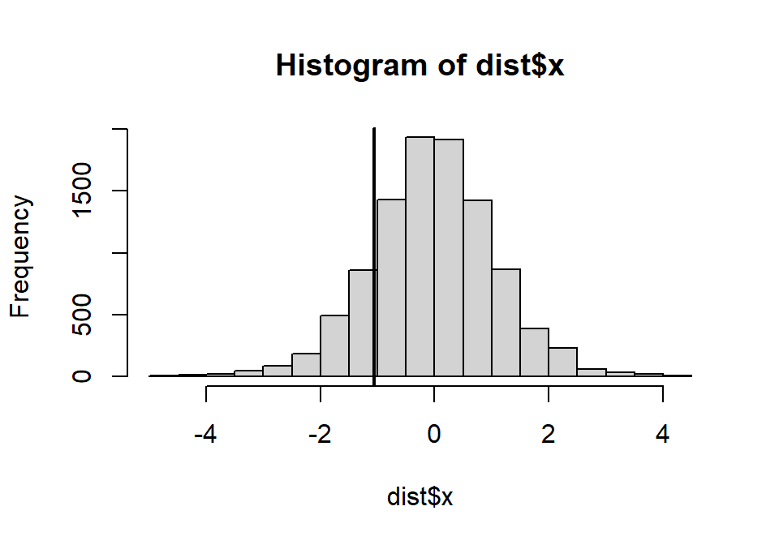

The sampling distribution of the difference

可以看出來，觀察值的統計量在這10000個新樣本中，並不那麼“極端”。觀察數據的排列置換法 $p$ 值為：

```r
#Use the distribution to obtain a p-value for the mean-difference by counting how many permuted mean-differences are more extreme than the one we observed in our actual data:
sum(abs(dist) > abs(t.test(dt$thyr ~ dt$group, var.equal = TRUE)$statistic))/10000
```

```
## [1] 0.3072
```

跟下面用參數檢驗法的 $p$ 值結果做一下對比，就會發現，其實二者的 $p$ 值結果十分接近。

```r
t.test(dt$thyr ~ dt$group, var.equal = TRUE)
```

```
##
##  Two Sample t-test
##
## data:  dt$thyr by dt$group
## t = -1.05935, df = 14, p-value = 0.30738
## alternative hypothesis: true difference in means between group Marked symptoms and group Slight or no symptoms is not equal to 0
## 95 percent confidence interval:
##  -43.256997  14.653823
## sample estimates:
##       mean in group Marked symptoms mean in group Slight or no symptoms
##                           42.142857                           56.444444
```

## 排列置換法三板斧

標題黨會不服，其實排列置換法的步驟不止三步 (笑)。

1. 在零假設的前提下，確認觀察數據所屬的組別，是可以任意對調的。(exchangeability) 有時候我們可能對數據進行一些轉換 (transforming)，以滿足這個要求。
2. 確認檢驗統計量 $T$，用 $T_{NULL}$ 標記。並且確定零假設時，檢驗統計量的期待值。(通常會用 $T_{NULL}=0$)
3. 計算觀察數據獲得的統計量 $T_0$。
4. 對觀察對象的組別進行 $N$ 次隨機排列組合。計算每次排列組合情況下的統計量 $(T_1, T_2, \cdots, T_N)$。
5. 計算 $(T_1, T_2, \cdots, T_N)$ 中比 $T_0$ 更極端的值所佔的比例 ($>|T_0|$)，作為觀察值 $T_0$ 的雙側 $p$ 值。

### 該如何選用合適的檢驗統計量 $T$？

在排列置換法中選用合適的檢驗統計量是一個需要仔細思考的過程。選用的 $T$ 必須要能反映組間的差異，並且要與話題相關。也希望能夠盡量和另假設時的統計量有一定的距離$T_{NULL}$。然而，選擇了不同的檢驗統計量並不意味著統計結果會有天差地別。最終常常是殊途同歸。另外，檢驗統計量並不一定要是一般參數檢驗時用到的統計量 ($t$ 或者其他的似然比檢驗)，因為我們不需要對統計量的精確度 (標準差標準誤等統統不要) 作判斷，本法的統計學推斷是通過排列置換的過程實現的。

### 可以在排列置換法中對其他變量進行統計學調整 (adjustment) 嗎？

用隨機對照試驗做例子。假如在實驗開始前的某個測量變量需要作為共變量被調整 (也就是要用 ANCOVA)，以獲得調整後的 $Y$ 差異。在零假設條件下，$Y_i$ 就不滿足可置換原則 (exchangeable)，因為那個需要被調整的測量變量可能決定了他們之間組別是有差異的。

此時，零假設條件 (沒有組間差異) 下，滿足可置換原則的其實是不考慮組別的情況下對需要校正的變量**進行線性回歸後獲得的殘差** $R_i$：

$$R_i = Y_i - \hat{Y}_i = Y_i - \hat\alpha - \hat\beta X_i$$

另假設條件下，只有殘差 $R_i$ 才滿足可置換原則，可以用在排列置換法中。當需要調整的變量個數增加時，同樣適用。

### 排列置換法，基於秩次的非參數檢驗之間的關係

如果你注意到，當我們把原始觀察數據排序之後進行的排序檢驗其實就是我們本章介紹的排列置換法。它在前面的秩次非參數檢驗中以特殊的形式展現。Good [@good2006permutation] 曾經說的好，“99% of common non-parametric tests are permutation tests in which the observations have been replaced by ranks. The sign is one notable exception.” 所以符號檢驗是非排序檢驗的特例。

### 排列置換檢驗法，是一種精確檢驗

複合型假設，指的是假設中只提及了所有分佈情況中的一種的例如：

$$\text{The mean of X is equal to }
0$$

相反，一個簡單假設，則是對參數分佈進行了詳細描述的假設：

$$X\sim N(0,4)$$

A test is said to be *exact* with respect to a compound hypothesis if the probability of making a type I error is exactly $\alpha$ for each and every one of the simple hypotheses that are subsumed within the compound hypothesis.

一個大家都聽說過的精確檢驗的例子就是 Fisher 精確檢驗法 (也是一種排列置換檢驗)。**所有的排列置換檢驗法都是精確檢驗法。**

## 基於排序置換檢驗法計算信賴區間

基於排序置換檢驗法的信賴區間計算，是一個有些許繁瑣的過程。我們可以設定多個不同的 $N_{NULL}$ ，但是樣本分佈相同的零假設時的統計量。計算相應的 $p$ 值，95% 信賴區間就是 $p$ 值保持大於等於 $0.05$的 $N_{NULL}$ 取值範圍。計算量將會是很大的。

用前面的例子來解釋就是，我們可以假設兩組之間甲狀腺素的差異是 $T_{NULL} = 10$，然後將第二組的觀察值全部加上10 (或者將第一組的觀察值全部減去10)，然後用前面描述的方法來檢驗兩組之間的差是否等於零，獲取 $p$ 值。然後用不同的 $T_{NULL}$ 取值，重複這個過程，直到找到上限和下限的 $T_{NULL}$ 值，他們的檢驗 $p$ 值都是0.05。

## 排序置換法的優缺點

優點：

1. 數據如果大大偏離了參數檢驗法的假設 (完全不是正態分佈)，本法則十分適用，且結果穩健 Robust；
2. 所有的排序置換法計算的 $p$ 值都是**精確**不需要近似的；
3. 排序置換法十分可靠，結果不會偏離對應的參數檢驗法，但是當你的數據樣本量很小，無法使用參數檢驗進行理想的統計分析時，排序置換法是極佳的選擇。

缺點：

1. 可置換原則必須得到滿足；
2. 消耗極大的運算能力，當數據量大時，計算過程將會很緩慢；(Windows的話可能直接就死機了，笑)
3. 用排序置換法計算信賴區間的過程比檢驗本身還好耗時費力。

# 自助重抽法 The bootstrap

## 定義

自助重抽，bootstrap 法是另一種對運算能力有較高要求的非參數檢驗常用手段。